# STAT/MATH 495: Problem Set 03

Jonathan Che

2017-09-26

# Question

For both `data1` and `data2` tibbles (a tibble is a data frame with some [metadata](https://blog.rstudio.com/2016/03/24/tibble-1-0-0#tibbles-vs-data-frames) attached):

- Find the splines model with the best out-of-sample predictive ability.
- Create a visualization arguing why you chose this particular model.
- Create a visualization of this model plotted over the given $(x_i, y_i)$ points for $i=1,\ldots,n=3000$.
- Give your estimate $\widehat{\sigma}$ of $\sigma$ where the noise component $\epsilon_i$ is distributed with mean 0 and standard deviation $\sigma$.

# Setup

First, I write a function that runs k-fold cross validation on spline models, using a given degrees of freedom and error metric.

```r
# Function to compute root mean square error (RMSE)
rmse <- function(x, y){
  return(sqrt(mean((x-y)^2)))
}

# Function to perform k-fold cross validation on splines model with given df
# Note: assumes single independent variable x and response variable y
kfold_cv_splines <- function(x, k, df,
                             error=rmse,
                             seed=123){
  # Randomly shuffle data frame (given random seed)
  set.seed(seed)
  x_shuffled <- x[sample(nrow(x)),]

  # Partition data frame into k folds
  # Note: naive method - final fold may have up to k
  # more observations than other folds
  partitions <- seq(from=1, to=nrow(x), by=nrow(x)%/%k)

  # Store separate data frames for each fold (k data frames in total)
  # in x_partitions
  # Note: assumes memory/x size is not an issue
  x_partitions <- list()
  for (i in 1:k){
    # Case for creating final fold
    if (i == length(partitions)){
      x_partition <- x_shuffled[partitions[i]:nrow(x_shuffled),]
    } else{
      next_i <- i+1
      x_partition <- x_shuffled[partitions[i]:(partitions[next_i]-1),]
    }
    x_partitions[[i]] <- x_partition
  }

  # Perform crossvalidation procedure
  # Store results of given error function in results_list
  results_list <- list()
  for (i in 1:k){
    test <- x_partitions[[i]]
    train <- data.table::rbindlist(x_partitions[-i])
    splines_model <- smooth.spline(x=train$x, y=train$y, df = df)
    results <- predict(splines_model, test$x)
    results_list[[i]] <- error(unlist(results[2], use.names=FALSE),
                               test$y)
  }

  # Return average error function output on k folds
  return(mean(unlist(results_list)))
}
```

# Data 1

Now, I run the function that I just created on `data1`. I examine degrees of freedom in a range from 2 to 50 and plot the results.

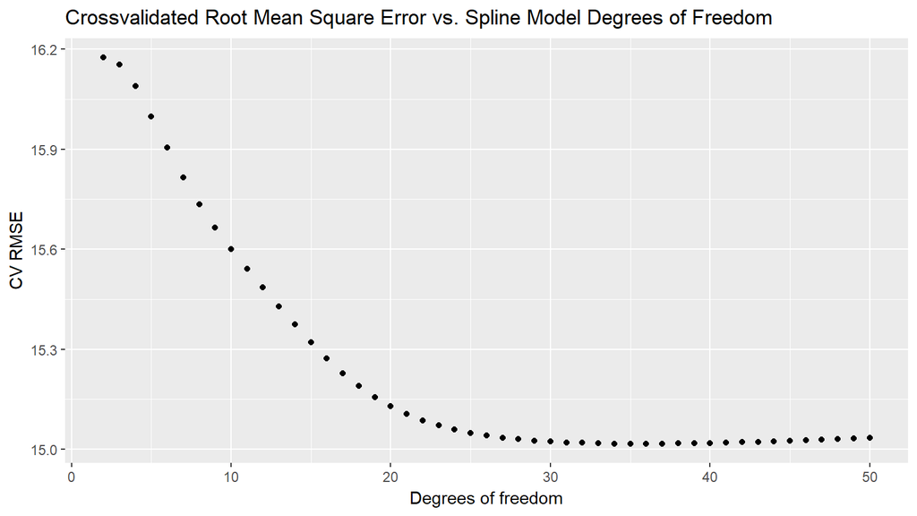

```r
# Set number of folds, degrees of freedom to test
k <- 10
dfs <- c(2:50)

# Run k-fold crossvalidation on given dfs and store results
results1 <- data.frame()
for (i in dfs){
  results1 <- rbind(results1, c(i, kfold_cv_splines(data1, k, i)))
}
names(results1) <- c("Degrees of freedom", "CV RMSE")

# Plot error against model df
ggplot(results1, aes(x=`Degrees of freedom`, y=`CV RMSE`)) +
  geom_point() +
  labs(title="Crossvalidated Root Mean Square Error vs. Spline Model Degrees of Freedom")
```

From the visualization, it seems that `df = 35` results in the optimal crossvalidated RMSE (i.e., minimum RMSE value). Let’s plot this model on the original data.

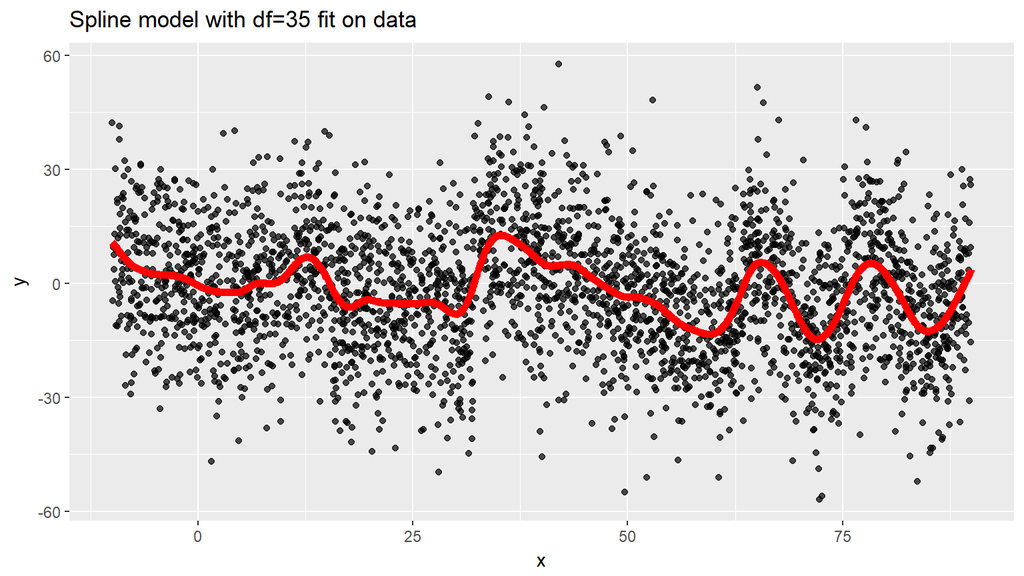

```r
splines_model_tidy1 <- smooth.spline(data1$x, data1$y, df=35) %>%
  broom::augment()
ggplot(splines_model_tidy1, aes(x=x)) +
  geom_point(aes(y=y), alpha=0.7) +
  geom_line(aes(y=.fitted), col="red", size=2) +
  labs(title="Spline model with df=35 fit on data")
```

The fit looks pretty good - we see that it matches up with some general patterns in the data without being too “wiggly”.

As a final measure, let’s try to compute an estimate $\widehat{\sigma_1}$ of $\sigma_1$ where we assume that the noise component $\epsilon_{1_i}$ is distributed with mean 0 and standard deviation $\sigma_1$.

```r
mean(splines_model_tidy1$.resid, na.rm=TRUE)
```

```
## [1] 0.003147314
```

```r
sd(splines_model_tidy1$.resid, na.rm=TRUE)
```

```
## [1] 14.87253
```

Our estimate of $\widehat{\sigma_1}$ is approximately 15

# Data 2

Now I repeat the entire process for `data2`. I examine degrees of freedom in a range from 2 to 50 and plot the results.

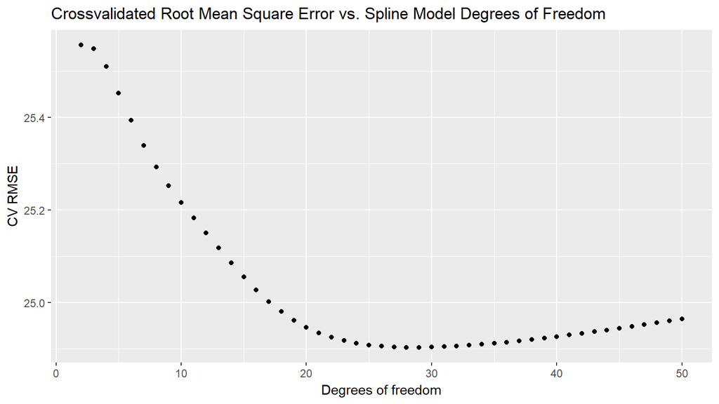

```r
# Set number of folds, degrees of freedom to test
k <- 10
dfs <- c(2:50)

# Run k-fold crossvalidation on given dfs and store results
results2 <- data.frame()
for (i in dfs){
  results2 <- rbind(results2, c(i, kfold_cv_splines(data2, k, i)))
}
names(results2) <- c("Degrees of freedom", "CV RMSE")

# Plot error against model df
ggplot(results2, aes(x=`Degrees of freedom`, y=`CV RMSE`)) +
  geom_point() +
  labs(title="Crossvalidated Root Mean Square Error vs. Spline Model Degrees of Freedom")
```

From the visualization, it seems that `df = 28` results in the optimal crossvalidated RMSE (i.e., minimum RMSE value). Let’s plot this model on the original data.

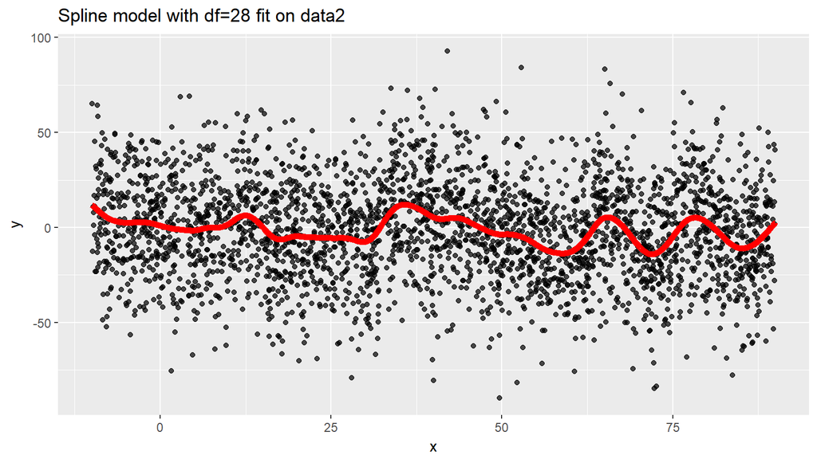

```r
splines_model_tidy2 <- smooth.spline(data2$x, data2$y, df=28) %>%
  broom::augment()
ggplot(splines_model_tidy2, aes(x=x)) +
  geom_point(aes(y=y), alpha=0.7) +
  geom_line(aes(y=.fitted), col="red", size=2) +
  labs(title="Spline model with df=28 fit on data2")
```

Again, the fit looks pretty good - we see that it matches up with some general patterns in the data without being too “wiggly”.

Finally, let’s compute an estimate $\widehat{\sigma_2}$ of $\sigma_2$ where we assume that the noise component $\epsilon_{2_i}$ is distributed with mean 0 and standard deviation $\sigma_2$.

```r
mean(splines_model_tidy2$.resid, na.rm=TRUE)
```

```
## [1] 0.005395095
```

```r
sd(splines_model_tidy2$.resid, na.rm=TRUE)
```

```
## [1] 24.71788
```

Our estimate of $\widehat{\sigma_2}$ is approximately 25.